# Starbucks Capstone Challenge

[output not shown]

[output cut: 15 more lines]

[output not shown]

[output cut: 15 more lines]

[output not shown]

[output cut: 15 more lines]

[output not shown]

[output cut: 15 more lines]

[output not shown]

[output cut: 15 more lines]

[output not shown]

[output cut: 14 more lines]

[output not shown]

[output cut: 14 more lines]

[output not shown]

[output cut: 14 more lines]

[output not shown]

[output cut: 14 more lines]

[output not shown]

[output cut: 14 more lines]

[output not shown]

[output cut: 14 more lines]

[output not shown]

[output cut: 14 more lines]

[output not shown]

[output cut: 14 more lines]

[output not shown]

[output cut: 14 more lines]

[output not shown]

[output cut: 14 more lines]

[output not shown]

[output cut: 14 more lines]

[output not shown]

[output cut: 14 more lines]

[output not shown]

[output cut: 14 more lines]

[output not shown]

[output cut: 14 more lines]

[output not shown]

[output cut: 14 more lines]

[output not shown]

[output cut: 14 more lines]

[output not shown]

[output cut: 14 more lines]

[output not shown]

[output cut: 14 more lines]

[output not shown]

[output cut: 15 more lines]

[output not shown]

[output not shown]

[output cut: 112 more lines]

[output not shown]

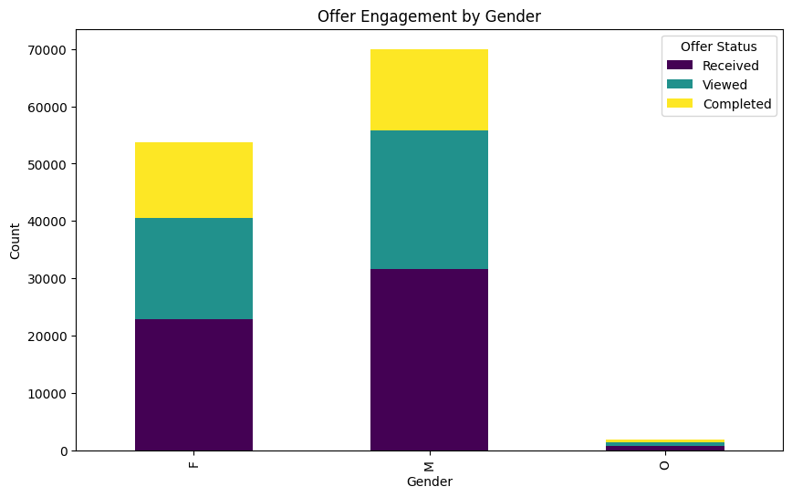

```python
# Group data by gender and offer status
gender_offer_stats = agg_transcript.groupby('gender')[['offer_received', 'offer_viewed', 'offer_completed']].sum()

gender_offer_stats.plot(kind='bar', stacked=True, figsize=(10, 6), colormap='viridis')
plt.xlabel("Gender")
plt.ylabel("Count")
plt.title("Offer Engagement by Gender")
plt.legend(title="Offer Status", labels=['Received', 'Viewed', 'Completed'])
plt.show()
```

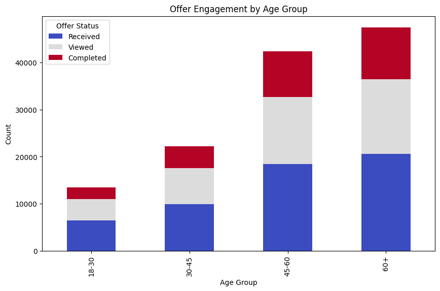

```python
bins = [18, 30, 45, 60, 120]
labels = ["18-30", "30-45", "45-60", "60+"]
agg_transcript['age_group'] = pd.cut(agg_transcript['age'], bins=bins, labels=labels, include_lowest=True)

age_offer_stats = agg_transcript.groupby('age_group')[['offer_received', 'offer_viewed', 'offer_completed']].sum()

age_offer_stats.plot(kind='bar', stacked=True, figsize=(10, 6), colormap='coolwarm')
plt.xlabel("Age Group")
plt.ylabel("Count")
plt.title("Offer Engagement by Age Group")
plt.legend(title="Offer Status", labels=['Received', 'Viewed', 'Completed'])
plt.show()
```

## Conclusiion & Recommendations:

`Gender-Based Engagement`

```
* Males received more offers overall compared to females.
* The percentage of offer completions remains high across genders, indicating that both groups are likely to act on promotions.
* However, a notable portion of received offers are not viewed, suggesting that engagement strategies (like personalized recommendations) could be improved.
```

`Age-Based Engagement`

```
* Older age groups (45-60, 60+) exhibit higher engagement rates in all stages: receiving, viewing, and completing offers.
* Younger age groups (18-30, 30-45) show lower offer completion rates despite receiving a significant number of offers.
* This indicates that younger customers may need different types of incentives or communication channels to drive engagement.
```

## Recommendations

`Targeted Promotions for Younger Customers`

```
* Since younger users tend to receive offers but not complete them, Starbucks should explore:
    - More engaging formats, mostly over Social media campaigns to reinforce the value of offers.
```

`Middled-Age + older customer``

```
- Since older customers show high offer completion rates, more BOGO and discount offers should be targeted toward them.
```

## ALERT~~~~~~

- A significant number of offers are received but not viewed. Starbucks should:
- Implement in-app reminders.
- Use email campaigns with personalized content based on previous offer interactions.

Below are some important links for XBG regularization params tuning:

https://xgboost.readthedocs.io/en/stable/parameter.html https://ml-cheatsheet.readthedocs.io/en/latest/regularization.html https://xgboost.readthedocs.io/en/stable/tutorials/param_tuning.html

## Official documents read and utilized:

Scikit-Learn (sklearn)Official Docs: https://scikit-learn.org/stable/user_guide.html Random Forest Classifier: https://scikit-learn.org/stable/modules/generated/sklearn.ensemble.RandomForestClassifier.html Logistic Regression: https://scikit-learn.org/stable/modules/generated/sklearn.linear_model.LogisticRegression.html XGBoost Classifier (Gradient Boosting): https://xgboost.readthedocs.io/en/stable/ GridSearchCV for Hyperparameter Tuning: https://scikit-learn.org/stable/modules/generated/sklearn.model_selection.GridSearchCV.html Accuracy: https://scikit-learn.org/stable/modules/generated/sklearn.metrics.accuracy_score.html Precision: https://scikit-learn.org/stable/modules/generated/sklearn.metrics.precision_score.html Recall: https://scikit-learn.org/stable/modules/generated/sklearn.metrics.recall_score.html F1-Score: https://scikit-learn.org/stable/modules/generated/sklearn.metrics.f1_score.html

```python
from subprocess import call
call(['python', '-m', 'nbconvert', 'Starbucks_Capstone_notebook.ipynb'])
```

[output not shown]

```
1
```